# Linear modeling

In summary, the behavioral data clearly demonstrates the relationship between raection time and correct responses, but only offers weak evidence that meth users perform poorly compared to non-meth users.

After eliminating 7899 non-response trials across the subjects, 132929 trials remain.

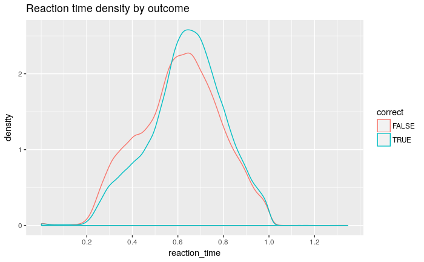

Correct trials clearly are somewhat slower than incorrect trials, indicating that waiting, on average, paid off for participants.

There is some sign of a bimodal distribution for the incorrect trials. A small number of trials may be clustered around 0.4 s, and then a second set clustered around 0.62 s, just a few milliseconds below the peak of the correct trials at 0.65 s.

I applied a logistic regression model to predict correct responses using reaction time, the position of each image in the segment, and the groups, presented as separate variables (MethUse and SexRisk), with subject ID as a random effect.

```r
mA2c<-glmer(correct~
                 #reaction_time+
                  presentation_n_in_segment+ #trial-level
                 #MethUse+
              SexRisk+(1|subid), #subject-level
               data = rl.all.subjects.list.clean,
            family = binomial, control=glmerControl(optimizer="Nelder_Mead"))
```

```r
mA2c.rt0<-glmer(correct~
                 reaction_time+presentation_n_in_segment+ #trial-level
                 MethUse+SexRisk+(1|subid), #subject-level
               data = rl.all.subjects.list.clean,family = binomial, control=glmerControl(optimizer="Nelder_Mead"))
summary(mA2c.rt0)
```

```
Generalized linear mixed model fit by maximum likelihood (Laplace Approximation) ['glmerMod']
 Family: binomial  ( logit )
Formula: correct ~ reaction_time + presentation_n_in_segment + MethUse +      SexRisk + (1 | subid)
   Data: rl.all.subjects.list.clean
Control: glmerControl(optimizer = "Nelder_Mead")

     AIC      BIC   logLik deviance df.resid
170140.1 170198.9 -85064.1 170128.1   132923

Scaled residuals:
    Min      1Q  Median      3Q     Max
-3.8694 -1.0155  0.5553  0.8108  1.6116

Random effects:
 Groups Name        Variance Std.Dev.
 subid  (Intercept) 0.1079   0.3285
Number of obs: 132929, groups:  subid, 171

Fixed effects:
                          Estimate Std. Error z value Pr(>|z|)
(Intercept)               -0.94342    0.05140  -18.36   <2e-16 ***
reaction_time              0.64505    0.03885   16.60   <2e-16 ***
presentation_n_in_segment  0.27428    0.00358   76.61   <2e-16 ***
MethUseTRUE               -0.14512    0.05953   -2.44   0.0148 *
SexRiskTRUE                0.10403    0.05613    1.85   0.0639 .
---
Signif. codes:  0 ‘***’ 0.001 ‘**’ 0.01 ‘*’ 0.05 ‘.’ 0.1 ‘ ’ 1

Correlation of Fixed Effects:
            (Intr) rctn_t prs___ MUTRUE
reaction_tm -0.478
prsnttn_n__ -0.235  0.034
MethUseTRUE -0.129 -0.009 -0.003
SexRiskTRUE -0.610  0.003  0.002 -0.282
```

```r
lm.beta.lmer(mA2c.rt0)
```

```
            reaction_time presentation_n_in_segment               MethUseTRUE               SexRiskTRUE
                0.2232772                 0.9506574                -0.1320974                 0.1015910
```

```r
anova(mA2c,mA2c.nomethuse.rt0,mA2c.rt0)
```

```
Data: rl.all.subjects.list.clean
Models:
mA2c: correct ~ presentation_n_in_segment + SexRisk + (1 | subid)
mA2c.nomethuse.rt0: correct ~ reaction_time + presentation_n_in_segment + SexRisk +
mA2c.nomethuse.rt0:     (1 | subid)
mA2c.rt0: correct ~ reaction_time + presentation_n_in_segment + MethUse +
mA2c.rt0:     SexRisk + (1 | subid)
                   Df    AIC    BIC logLik deviance    Chisq Chi Df Pr(>Chisq)
mA2c                4 170417 170456 -85204   170409
mA2c.nomethuse.rt0  5 170144 170193 -85067   170134 274.6366      1    < 2e-16 ***
mA2c.rt0            6 170140 170199 -85064   170128   5.8395      1    0.01567 *
---
Signif. codes:  0 ‘***’ 0.001 ‘**’ 0.01 ‘*’ 0.05 ‘.’ 0.1 ‘ ’ 1
```

An ANOVA comparison of the models offers unambiguous evidence with a strong difference in both AIC and BIC that adding reaction to the model improves its prediction of a correct response. However, the addition of MethUse as a predictor only improves AIC slightly, by 4 points, and the BIC, which more strongly peanlizes model complexity, suggests that the model including MethUse is not as powerful.

```r
# does eliminating reaction time change the prediction?
# in other words, does reaction time carry useful information which might be moderating the rleationship between corrct and MethUse/SexRisk; is reaction time a NEGATIVE CONFOUNDER?
mA2c.noreactiontime<-glmer(correct~
                             presentation_n_in_segment+ #trial-level
                             MethUse+SexRisk+(1|subid), #subject-level
                           data = rl.all.subjects.list.clean,family = binomial, control=glmerControl(optimizer="Nelder_Mead"))
summary(mA2c.noreactiontime)
```

```
Generalized linear mixed model fit by maximum likelihood (Laplace Approximation) ['glmerMod']
 Family: binomial  ( logit )
Formula: correct ~ presentation_n_in_segment + MethUse + SexRisk + (1 |      subid)
   Data: rl.all.subjects.list.clean
Control: glmerControl(optimizer = "Nelder_Mead")

     AIC      BIC   logLik deviance df.resid
170414.2 170463.2 -85202.1 170404.2   132924

Scaled residuals:
    Min      1Q  Median      3Q     Max
-3.6928 -1.0211  0.5544  0.8142  1.5037

Random effects:
 Groups Name        Variance Std.Dev.
 subid  (Intercept) 0.1291   0.3593
Number of obs: 132929, groups:  subid, 171

Fixed effects:
                           Estimate Std. Error z value Pr(>|z|)
(Intercept)               -0.536801   0.049022  -10.95   <2e-16 ***
presentation_n_in_segment  0.272839   0.003575   76.31   <2e-16 ***
MethUseTRUE               -0.136685   0.064934   -2.10   0.0353 *
SexRiskTRUE                0.100966   0.061277    1.65   0.0994 .
---
Signif. codes:  0 ‘***’ 0.001 ‘**’ 0.01 ‘*’ 0.05 ‘.’ 0.1 ‘ ’ 1

Correlation of Fixed Effects:
            (Intr) prs___ MUTRUE
prsnttn_n__ -0.230
MethUseTRUE -0.152 -0.002
SexRiskTRUE -0.697  0.002 -0.282
```

```r
#looking at this - the regression coefficients for MethUse and SexRisk appear to disappear
#Reaction time may be a negative confounder.
#https://www.researchgate.net/post/Why_in_regression_analysis_does_the_inclusion_of_a_new_variable_makes_other_variables_that_previously_were_not_statistically_significant
mA2c.rt.interact<-glmer(correct~
                 reaction_time+presentation_n_in_segment+ #trial-level
                 MethUse*reaction_time+SexRisk*reaction_time+(1|subid), #subject-level
               data = rl.all.subjects.list.clean,family = binomial, control=glmerControl(optimizer="Nelder_Mead"))
summary(mA2c.rt.interact)
```

```
Generalized linear mixed model fit by maximum likelihood (Laplace Approximation) ['glmerMod']
 Family: binomial  ( logit )
Formula: correct ~ reaction_time + presentation_n_in_segment + MethUse *      reaction_time + SexRisk * reaction_time + (1 | subid)
   Data: rl.all.subjects.list.clean
Control: glmerControl(optimizer = "Nelder_Mead")

     AIC      BIC   logLik deviance df.resid
170140.4 170218.8 -85062.2 170124.4   132921

Scaled residuals:
    Min      1Q  Median      3Q     Max
-3.8463 -1.0162  0.5551  0.8108  1.6087

Random effects:
 Groups Name        Variance Std.Dev.
 subid  (Intercept) 0.1086   0.3295
Number of obs: 132929, groups:  subid, 171

Fixed effects:
                          Estimate Std. Error z value Pr(>|z|)
(Intercept)               -0.99631    0.06024  -16.54  < 2e-16 ***
reaction_time              0.72982    0.06354   11.49  < 2e-16 ***
presentation_n_in_segment  0.27425    0.00358   76.60  < 2e-16 ***
MethUseTRUE               -0.17677    0.08201   -2.16  0.03113 *
SexRiskTRUE                0.20433    0.07676    2.66  0.00777 **
reaction_time:MethUseTRUE  0.05032    0.08954    0.56  0.57410
reaction_time:SexRiskTRUE -0.16077    0.08371   -1.92  0.05477 .
---
Signif. codes:  0 ‘***’ 0.001 ‘**’ 0.01 ‘*’ 0.05 ‘.’ 0.1 ‘ ’ 1

Correlation of Fixed Effects:
            (Intr) rctn_t prs___ MUTRUE SRTRUE r_:MUT
reaction_tm -0.660
prsnttn_n__ -0.199  0.018
MethUseTRUE -0.150  0.105 -0.001
SexRiskTRUE -0.690  0.469 -0.001 -0.295
rct_:MUTRUE  0.102 -0.159 -0.001 -0.686  0.211
rct_:SRTRUE  0.453 -0.689  0.003  0.211 -0.680 -0.307
```